# **Time Series Analysis on Cat Sketch data**

#### *by Jayawardana Wickramasinghe Pathiranage Lakindu Ransika (3036094631)*

## Importing libaries and functions

```python
import json
import itertools
import numpy as np
import pandas as pd
import matplotlib.pyplot as plt
from statsmodels.graphics.tsaplots import plot_acf, plot_pacf
from statsmodels.tsa.stattools import acf, pacf, adfuller
from statsmodels.tsa.ar_model import AutoReg
from statsmodels.tsa.arima.model import ARIMA
from statsmodels.tsa.statespace.varmax import VARMAX
from statsmodels.stats.diagnostic import acorr_ljungbox
from scipy import stats
from scipy.stats import shapiro, norm, boxcox
import warnings

warnings.filterwarnings('ignore') # clean presentation
np.random.seed(4601) # Set random state so any randomness is reproducible
plt.rcParams.update({'font.size': 14}) # for clarity
```

## **Part 1: Modelling Distance from the Center of the Drawing using ARIMA**

### Data Processing, Feature Engineering and EDA

```python
# Select drawing
index = 56430 # Drawing was chosen
seq = np.load("cat_56430.npy")
x = seq[:, 1]
y = seq[:, 2]

# Calculate distance from center (feature engineering)
# Center is defined as the (mean(x), mean(y))
center_x = np.mean(x)
center_y = np.mean(y)
distance_from_center = np.sqrt((x - center_x)**2 + (y - center_y)**2)

# Use sequence index as time (0, 1, 2, ...)
time_steps = np.arange(len(seq))

# Processed data: [sequence_index, x, y, distance_from_center]
# distance_from_center is the main focus of the project
# x and y will be used at the very end for a 2D VARIMA model and "forecast drift analysis"
processed_data = np.column_stack([time_steps, x, y, distance_from_center])

print(f"Processed data shape: {processed_data.shape}")
print(f"Columns: [sequence_index, x, y, distance_from_center]")
```

```
Processed data shape: (197, 4)
Columns: [sequence_index, x, y, distance_from_center]
```

```python
# Show processed data
processed_data[:5, :]
```

```
array([[  0.        , 731.        ,  99.        , 168.01400582],
       [  1.        , 726.        ,  97.        , 166.08838256],
       [  2.        , 720.        ,  95.        , 163.67409291],
       [  3.        , 712.        ,  93.        , 160.25446313],
       [  4.        , 704.        ,  92.        , 156.36971534]])
```

```python
min_val = distance_from_center.min()
print(f"Original data range: [{min_val:.4f}, {distance_from_center.max():.4f}]")
```

```
Original data range: [32.4844, 268.3263]
```

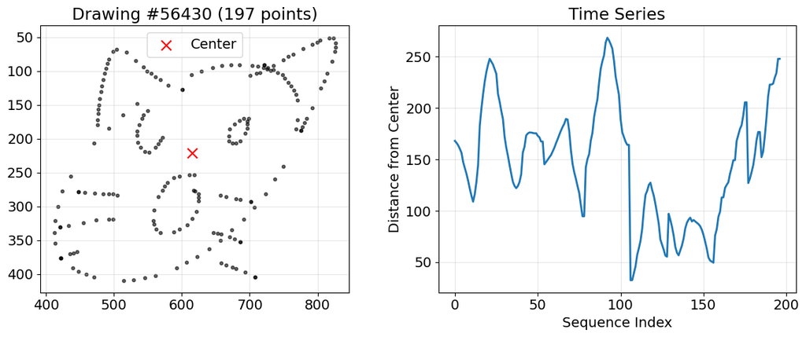

```python
# Plot chosen drawing and distance_from_center time plot
def plot_drawing_and_timeseries(time_steps, x, y, center_x, center_y, distance_from_center, index):
    """Plot drawing and its time series"""
    fig, axes = plt.subplots(1, 2, figsize=(12, 5))

    # Drawing
    axes[0].scatter(x, y, c='black', s=10, alpha=0.6)
    axes[0].scatter(center_x, center_y, color='red', s=100, marker='x', label='Center')
    axes[0].set_aspect('equal')
    axes[0].invert_yaxis()
    axes[0].set_title(f'Drawing #{index} ({len(x)} points)')
    axes[0].legend()
    axes[0].grid(True, alpha=0.3)

    # Distance from center time series
    axes[1].plot(time_steps, distance_from_center, linewidth=2)
    axes[1].set_xlabel('Sequence Index')
    axes[1].set_ylabel('Distance from Center')
    axes[1].set_title('Time Series')
    axes[1].grid(True, alpha=0.3)

    plt.tight_layout()
    plt.show()

# Time plot shows that there is pattern for distance_from_center (i.e. not random noise)
plot_drawing_and_timeseries(time_steps, x, y, center_x, center_y, distance_from_center, index)
```

**Comments**

- Time plot highlights both non-stationarity in variance and mean. This highlights a need for differencing and variance stabilizing transformation.
- For completion, note that distance is positive (trivial).

**Next Steps**

- Non-stationarity in variance would be handled first as differencing may result in negative values.

### Handling non-stationarity in variance

```
================================================================================
FINDING THE OPTIMAL TRANSFORMATION
================================================================================
Box-Cox optimal λ: 0.8037

Total transformations: 7

================================================================================
TRANSFORMED TIME PLOT AND DISTRIBUTION PLOT
================================================================================
```

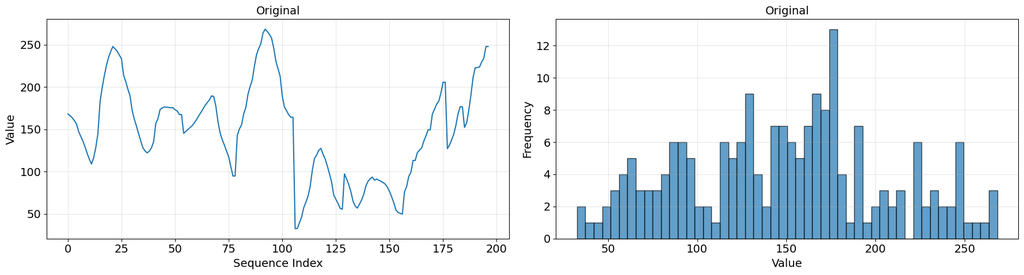

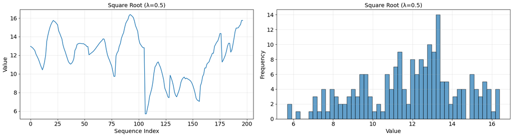

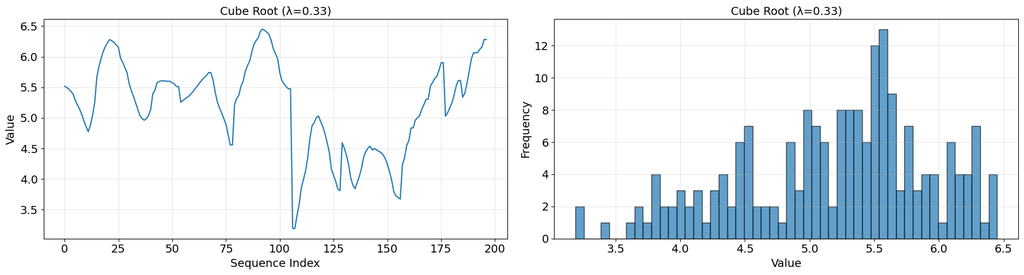

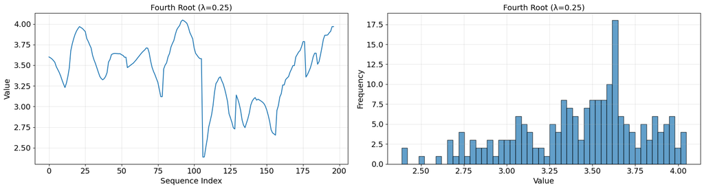

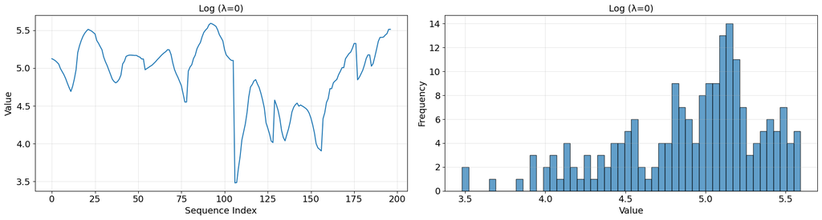

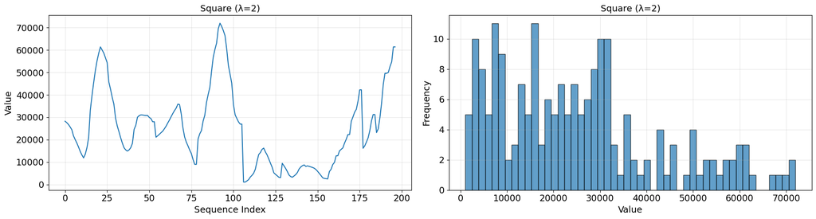

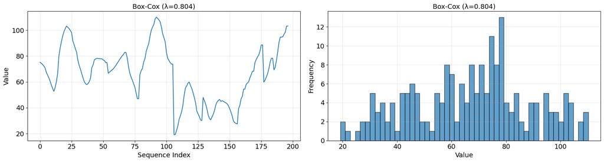

```python
# STEP 1: Finding the optimal transformation
print("\n" + "="*80)
print("Finding the optimal transformation".upper())
print("="*80)

transformations = {}

# Original
transformations['Original'] = distance_from_center

# Some common transformations for visualizing time plot
transformations['Square Root (λ=0.5)'] = np.sqrt(distance_from_center)
transformations['Cube Root (λ=0.33)'] = np.power(distance_from_center, 1/3)
transformations['Fourth Root (λ=0.25)'] = np.power(distance_from_center, 0.25)
transformations['Log (λ=0)'] = np.log(distance_from_center)
transformations['Square (λ=2)'] = np.power(distance_from_center, 2)

# Use Box-Cox's in-built optimiser to find the optimal lambda (last plot)
boxcox_data, lambda_boxcox = boxcox(distance_from_center)
transformations[f'Box-Cox (λ={lambda_boxcox:.3f})'] = boxcox_data
print(f"Box-Cox optimal λ: {lambda_boxcox:.4f}")

print(f"\nTotal transformations: {len(transformations)}")

# Step 2: Print the transformed time plot and distribution plot side by side
print("\n" + "="*80)
print("Transformed Time Plot and Distribution plot".upper())
print("="*80)

for name, data in transformations.items():
    fig, axes = plt.subplots(1, 2, figsize=(18, 5))

    # Time series
    axes[0].plot(time_steps, data, linewidth=1.5)
    axes[0].set_title(f'{name}', fontsize=14)
    axes[0].set_xlabel('Sequence Index')
    axes[0].set_ylabel('Value')
    axes[0].grid(True, alpha=0.3)

    # Distribution
    axes[1].hist(data, bins=50, edgecolor='black', alpha=0.7)
    axes[1].set_title(f'{name}', fontsize=14)
    axes[1].set_xlabel('Value')
    axes[1].set_ylabel('Frequency')
    axes[1].grid(True, alpha=0.3)

    plt.tight_layout()
    plt.show()
```

**Comments**

- For the time series plot, it is either very similar to the original after transformation or much worse.

**Next Steps**

- No transformation would be used.
- Check for non-stationarity in mean more robustly using ACF.

### Check for non-stationarity in mean robustly

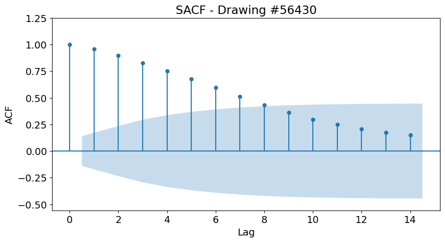

```python
# Find nlags using sqrt of sample size
nlags = (distance_from_center.shape[0]**0.5//1)

# Calculate ACF with confidence intervals
acf_vals, acf_confint = acf(distance_from_center, nlags=nlags, alpha=0.05)

# Visualize ACF plot
fig, axes = plt.subplots(figsize=(10, 5))
plot_acf(distance_from_center, lags=nlags, ax=axes, auto_ylims=True)
axes.set_title(f'SACF - Drawing #{index}')
axes.set_xlabel('Lag')
axes.set_ylabel('ACF')
plt.show()
```

**Comments**

- ACF decays slowly. This indicates non-stationarity.

**Next Steps**

- Therefore, model will be differenced.

### Handling non-stationarity via differencing

```python
# First-order differencing
differenced_data = np.diff(distance_from_center)

print(f"Original length: {len(distance_from_center)}")
print(f"Differenced length: {len(differenced_data)}")
print(f"Differenced range: [{differenced_data.min():.4f}, {differenced_data.max():.4f}]")
print(f"Differenced mean: {differenced_data.mean():.4f}")
print(f"Differenced std: {differenced_data.std():.4f}")
```

```
Original length: 197
Differenced length: 196
Differenced range: [-131.6873, 47.7515]
Differenced mean: 0.4073
Differenced std: 15.0022
```

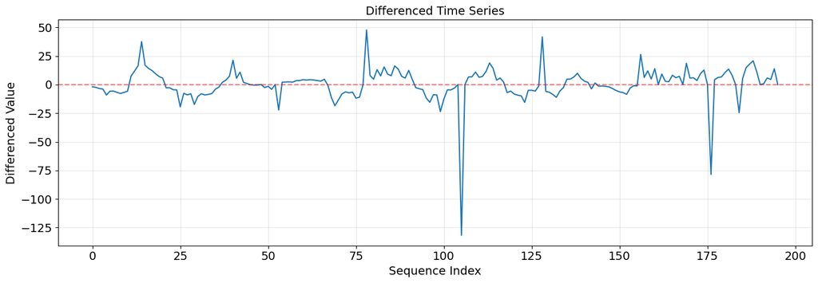

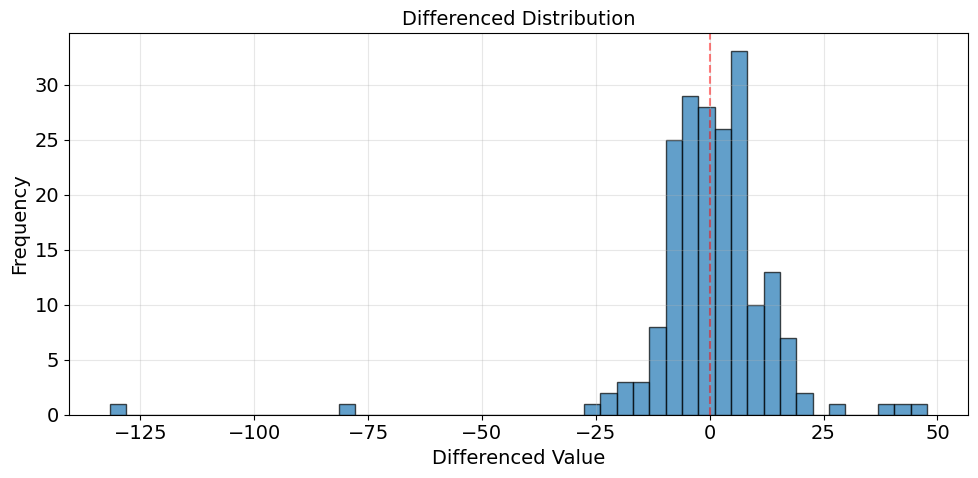

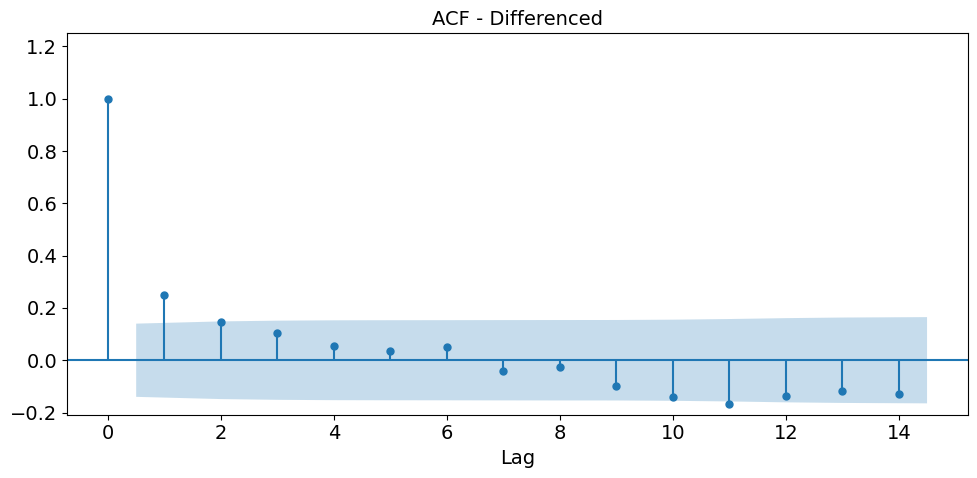

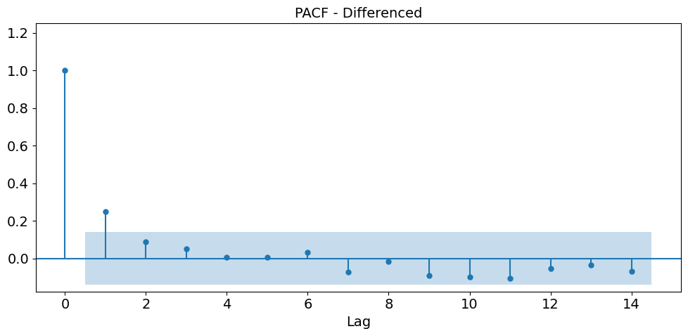

```python
# Differenced time plot
fig, ax = plt.subplots(figsize=(14, 5))
ax.plot(differenced_data, linewidth=1.5)
ax.set_title('Differenced Time Series', fontsize=14)
ax.set_xlabel('Sequence Index')
ax.set_ylabel('Differenced Value')
ax.axhline(y=0, color='r', linestyle='--', alpha=0.5)
ax.grid(True, alpha=0.3)
plt.tight_layout()
plt.show()

# Differenced distribution plot
fig, ax = plt.subplots(figsize=(10, 5))
ax.hist(differenced_data, bins=50, edgecolor='black', alpha=0.7)
ax.set_title('Differenced Distribution', fontsize=14)
ax.set_xlabel('Differenced Value')
ax.set_ylabel('Frequency')
ax.axvline(x=0, color='r', linestyle='--', alpha=0.5)
ax.grid(True, alpha=0.3)
plt.tight_layout()
plt.show()

# Differenced ACF
fig, ax = plt.subplots(figsize=(10, 5))
plot_acf(differenced_data, lags=nlags, ax=ax, auto_ylims=True)
ax.set_title('ACF - Differenced', fontsize=14)
ax.set_xlabel('Lag')
plt.tight_layout()
plt.show()

fig, ax = plt.subplots(figsize=(10, 5))
plot_pacf(differenced_data, lags=nlags, ax=ax, auto_ylims=True)
ax.set_title('PACF - Differenced', fontsize=14)
ax.set_xlabel('Lag')
plt.tight_layout()
plt.show()
```

**Comments**

**Next Steps**

- Use PACF or ACF to determine the first model.

### Determing first model using ACF or PACF

```
Using 14.0 lags for analysis


================================================================================
SIGNIFICANT LAGS
================================================================================
ACF - Significant Lags:
  [0, 1, 11]
  Total: 3 out of 15 lags


================================================================================
PLOTS
================================================================================
```

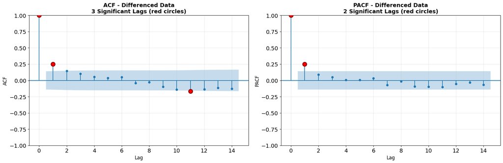

```python
# STEP 1: Calculate ACF & PACF with 95% confidence intervals
print(f"Using {nlags} lags for analysis\n")

acf_vals, acf_confint = acf(differenced_data, nlags=nlags, alpha=0.05)
pacf_vals, pacf_confint = pacf(differenced_data, nlags=nlags, alpha=0.05)


# STEP 2: Find significant lags (outside bounds)
# ACF
acf_significant_lags = []
for lag in range(len(acf_vals)):
    lower, upper = acf_confint[lag]
    if 0 < lower or 0 > upper:  # 0 is outside [lower, upper]
        acf_significant_lags.append(lag)
# Find PACF
pacf_significant_lags = []
for lag in range(len(pacf_vals)):
    lower, upper = pacf_confint[lag]
    if 0 < lower or 0 > upper:
        pacf_significant_lags.append(lag)

print("\n" + "="*80)
print("SIGNIFICANT LAGS")
print("="*80)
print("ACF - Significant Lags:")
print(f"  {acf_significant_lags}")
print(f"  Total: {len(acf_significant_lags)} out of {len(acf_vals)} lags\n")


# STEP 3: ACF and PACF plots
print("\n" + "="*80)
print("PLOTS")
print("="*80)

fig, axes = plt.subplots(1, 2, figsize=(18, 6))

# ACF Plot
plot_acf(differenced_data, lags=nlags, ax=axes[0])
for lag in acf_significant_lags:
    if lag <= nlags:
        axes[0].scatter(lag, acf_vals[lag], color='red', s=100, zorder=5,
                       marker='o', edgecolors='darkred', linewidths=2)
axes[0].set_title(f'ACF - Differenced Data\n{len(acf_significant_lags)} Significant Lags (red circles)',
                 fontsize=14, fontweight='bold')
axes[0].set_xlabel('Lag', fontsize=12)
axes[0].set_ylabel('ACF', fontsize=12)
axes[0].grid(True, alpha=0.3)

# PACF Plot
plot_pacf(differenced_data, lags=nlags, ax=axes[1])
for lag in pacf_significant_lags:
    if lag <= nlags:
        axes[1].scatter(lag, pacf_vals[lag], color='red', s=100, zorder=5,
                       marker='o', edgecolors='darkred', linewidths=2)
axes[1].set_title(f'PACF - Differenced Data\n{len(pacf_significant_lags)} Significant Lags (red circles)',
                 fontsize=14, fontweight='bold')
axes[1].set_xlabel('Lag', fontsize=12)
axes[1].set_ylabel('PACF', fontsize=12)
axes[1].grid(True, alpha=0.3)

plt.tight_layout()
plt.show()
```

**Comments**

- Domain knowledge: Current time series uses differenced position. In drawing the next change in position is affected by the previous change in position. For example, if you are drawing a diagonal you are more likely to drag the cursor along that diagonal. Same applies to other shapes. Therefore, AR model is more suited.
- Moreover, PACF has no later lags. Therefore, it requires no additional justification for borderline cases.
- Given both these, PACF will be used to determine the next model.
- The model chosen in AR(1).

**Next Steps**

- Fit AR(1) model.
- Fitted AR(1) model diagnostics.

### Fiting first model AR(1) and model diagnostics

```python
# Fit AR(1)
ar1_model = AutoReg(differenced_data, lags=1)
ar1_fitted = ar1_model.fit()

print(ar1_fitted.summary())
```

```
                            AutoReg Model Results
==============================================================================
Dep. Variable:                      y   No. Observations:                  196
Model:                     AutoReg(1)   Log Likelihood                -798.965
Method:               Conditional MLE   S.D. of innovations             14.561
Date:                Mon, 01 Dec 2025   AIC                           1603.930
Time:                        20:23:55   BIC                           1613.749
Sample:                             1   HQIC                          1607.905
                                  196
==============================================================================
                 coef    std err          z      P>|z|      [0.025      0.975]
------------------------------------------------------------------------------
const          0.3167      1.043      0.304      0.761      -1.728       2.361
y.L1           0.2504      0.069      3.612      0.000       0.115       0.386
                                    Roots
=============================================================================
                  Real          Imaginary           Modulus         Frequency
-----------------------------------------------------------------------------
AR.1            3.9938           +0.0000j            3.9938            0.0000
-----------------------------------------------------------------------------
```

```python
# Print model parameters
intercept = ar1_fitted.params[0]
ar_coef = ar1_fitted.params[1]

print(f"Intercept (c):     {intercept:.6f}")
print(f"AR(1) coefficient: {ar_coef:.6f}")
print(f"\nModel equation:")
print(f"y[t] = {intercept:.4f} + {ar_coef:.4f}*y[t-1] + a[t]")
```

```
Intercept (c):     0.316746
AR(1) coefficient: 0.250387

Model equation:
y[t] = 0.3167 + 0.2504*y[t-1] + a[t]
```

```
================================================================================
VISUALIZATIONS
================================================================================
```

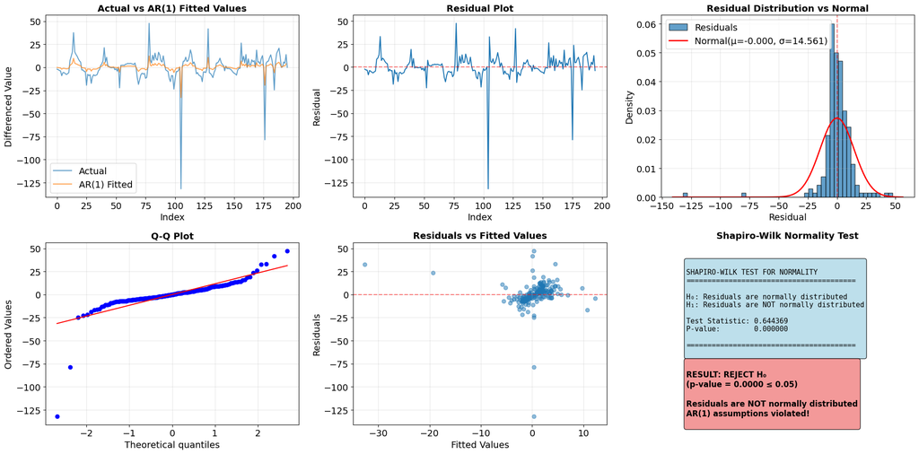

```
================================================================================
RESIDUAL STATISTICS
================================================================================
  Mean:     -0.000000
  Std Dev:  14.5606
  Skewness: -4.1938
  Kurtosis: 37.5743
================================================================================
```

```python
# Model Diagnostics (normality and residuals)
# Visualisations
print("\n" + "="*80)
print("VISUALIZATIONS")
print("="*80)


predictions = ar1_fitted.fittedvalues
residuals = ar1_fitted.resid

fig, axes = plt.subplots(2, 3, figsize=(20, 10))

# Plot 1: Actual vs Fitted
axes[0, 0].plot(differenced_data, label='Actual', linewidth=1.5, alpha=0.7)
axes[0, 0].plot(predictions, label='AR(1) Fitted', linewidth=1.5, alpha=0.7)
axes[0, 0].set_title('Actual vs AR(1) Fitted Values', fontsize=14, fontweight='bold')
axes[0, 0].set_xlabel('Index')
axes[0, 0].set_ylabel('Differenced Value')
axes[0, 0].legend()
axes[0, 0].grid(True, alpha=0.3)

# Plot 2: Residual plot
axes[0, 1].plot(residuals, linewidth=1.5)
axes[0, 1].axhline(y=0, color='r', linestyle='--', alpha=0.5)
axes[0, 1].set_title('Residual Plot', fontsize=14, fontweight='bold')
axes[0, 1].set_xlabel('Index')
axes[0, 1].set_ylabel('Residual')
axes[0, 1].grid(True, alpha=0.3)

# Plot 3: Residual distribution with normal overlay plot
# Residual
axes[0, 2].hist(residuals, bins=50, edgecolor='black', alpha=0.7, density=True, label='Residuals')
axes[0, 2].axvline(x=0, color='r', linestyle='--', alpha=0.5)

# Overlay normal distribution
mu, std = residuals.mean(), residuals.std()
xmin, xmax = axes[0, 2].get_xlim()
x = np.linspace(xmin, xmax, 100)
p = norm.pdf(x, mu, std)
axes[0, 2].plot(x, p, 'r-', linewidth=2, label=f'Normal(μ={mu:.3f}, σ={std:.3f})')

axes[0, 2].set_title('Residual Distribution vs Normal', fontsize=14, fontweight='bold')
axes[0, 2].set_xlabel('Residual')
axes[0, 2].set_ylabel('Density')
axes[0, 2].legend()
axes[0, 2].grid(True, alpha=0.3)

# Plot 4: Q-Q Plot
stats.probplot(residuals, dist="norm", plot=axes[1, 0])
axes[1, 0].set_title('Q-Q Plot', fontsize=14, fontweight='bold')
axes[1, 0].grid(True, alpha=0.3)

# Plot 5: Residual scatter plot
axes[1, 1].scatter(predictions, residuals, alpha=0.5)
axes[1, 1].axhline(y=0, color='r', linestyle='--', alpha=0.5)
axes[1, 1].set_title('Residuals vs Fitted Values', fontsize=14, fontweight='bold')
axes[1, 1].set_xlabel('Fitted Values')
axes[1, 1].set_ylabel('Residuals')
axes[1, 1].grid(True, alpha=0.3)

# Plot 6: Shapiro-Wilk Test Result
axes[1, 2].axis('off')
axes[1, 2].set_title('Shapiro-Wilk Normality Test', fontsize=14, fontweight='bold')

# Perform Shapiro-Wilk test
shapiro_stat, shapiro_pvalue = shapiro(residuals)

# Create text summary
test_text = f"""
SHAPIRO-WILK TEST FOR NORMALITY
{'='*40}

H₀: Residuals are normally distributed
H₁: Residuals are NOT normally distributed

Test Statistic: {shapiro_stat:.6f}
P-value:        {shapiro_pvalue:.6f}

{'='*40}
"""

if shapiro_pvalue > 0.05:
    result_text = f"""
RESULT: ACCEPT H₀
(p-value = {shapiro_pvalue:.4f} > 0.05)

Residuals ARE normally distributed
AR(1) assumptions satisfied!
"""
    color = 'lightgreen'
else:
    result_text = f"""
RESULT: REJECT H₀
(p-value = {shapiro_pvalue:.4f} ≤ 0.05)

Residuals are NOT normally distributed
AR(1) assumptions violated!
"""
    color = 'lightcoral'

axes[1, 2].text(0.1, 0.9, test_text, transform=axes[1, 2].transAxes,
                fontsize=11, verticalalignment='top', fontfamily='monospace',
                bbox=dict(boxstyle='round', facecolor='lightblue', alpha=0.8))

axes[1, 2].text(0.1, 0.35, result_text, transform=axes[1, 2].transAxes,
                fontsize=12, verticalalignment='top', fontweight='bold',
                bbox=dict(boxstyle='round', facecolor=color, alpha=0.8))

plt.tight_layout()
plt.show()

# Residual statistics
print("\n" + "="*80)
print("Residual Statistics".upper())
print("="*80)

print(f"  Mean:     {residuals.mean():.6f}")
print(f"  Std Dev:  {residuals.std():.4f}")
print(f"  Skewness: {stats.skew(residuals):.4f}")
print(f"  Kurtosis: {stats.kurtosis(residuals):.4f}")

print("="*80)
```

**Comments**

- **Time Plot**
  - Except for the occasional spikes, the time plot seems to be mostly random noise.
  - Hence, residuals are mostly white noise.
- **Normality**
  - Distribution plot: The distribution is centered around zero. The distribution is also more peaked compared to normal and negatively skewed (aligns with calcuated skewness).
  - q-q plot: Normality seems acceptable if outliers are excluded.
  - Shapiro-Wilk test: Not normal.
  - Kurtosis: Indicates heavily tailednes, but I think this is due to the few outliers.
- **Conclusion**
  - The failure of the Shapiro-Wilk test and the non-normality of other indicators are most likely due to the presence of outliers.

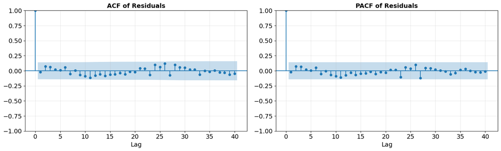

```
================================================================================
LJUNG-BOX TEST FOR WHITE NOISE RESIDUALS
================================================================================
     lb_stat  lb_pvalue
14  12.26092   0.585358
```

```python
# Model Diagnostics (ACF and PACF)
fig, axes = plt.subplots(1, 2, figsize=(16, 5))

# ACF of residuals
plot_acf(residuals, lags=40, ax=axes[0])
axes[0].set_title('ACF of Residuals',
                  fontsize=14, fontweight='bold')
axes[0].grid(True, alpha=0.3)
axes[0].set_xlabel("Lag")

# PACF of residuals
plot_pacf(residuals, lags=40, ax=axes[1])
axes[1].set_title('PACF of Residuals',
                  fontsize=14, fontweight='bold')
axes[1].grid(True, alpha=0.3)
axes[1].set_xlabel("Lag")

plt.tight_layout()
plt.show()

lb_test = acorr_ljungbox(residuals, lags=[nlags], return_df=True)

print("\n" + "="*80)
print("LJUNG-BOX TEST FOR WHITE NOISE RESIDUALS")
print("="*80)
print(lb_test)
```

**Comments**

- **ACF and PACF**
  - ACF and PACF plots indicate that there is no signal in the residuals when considered in isolation.
  - This suggests that the residuals are white noise.
- **Ljung-Box Test**
  - Ljung-Box test indicates that there is no signal in the residuals jointly.
  - This suggests that the residuals are white noise.
- **Conclusion**
  - Residuals are white noise.

**Comments**

- There is no issue with the time plot and residuals are white noise/
- However, residuals do not follow normal distribution despite being centered around zero.
- Hypothesis: The failure of normality is most likely due to the presence of outliers.

**Next Steps**

- Remove the residual outliers and repeat the residuals analysis.
- Outliers would be detected using the 1.5*IQR method.

### Residual Analysis Post-Outlier Removal using IQR bound

```python
residuals_array = np.array(residuals)

# IQR Method
Q1 = np.percentile(residuals_array, 25)
Q3 = np.percentile(residuals_array, 75)
IQR = Q3 - Q1
lower_bound = Q1 - 1.5 * IQR
upper_bound = Q3 + 1.5 * IQR
outliers = np.where((residuals_array < lower_bound) | (residuals_array > upper_bound))[0]

print(f"Outliers detected: {len(outliers)}")
```

```
Outliers detected: 11
```

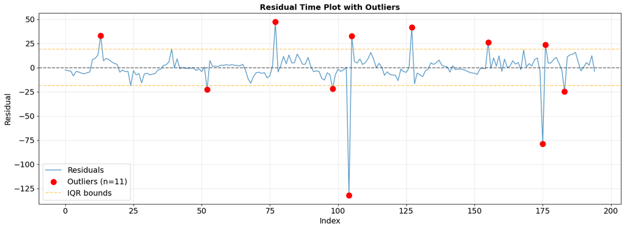

```python
# Residual time plot with outliers
fig, ax = plt.subplots(figsize=(16, 6))

ax.plot(residuals_array, linewidth=1.5, alpha=0.7, label='Residuals')
ax.scatter(outliers, residuals_array[outliers],
           color='red', s=100, zorder=5, label=f'Outliers (n={len(outliers)})')
ax.axhline(y=0, color='black', linestyle='--', alpha=0.5)
ax.axhline(y=upper_bound, color='orange', linestyle='--', alpha=0.5, label='IQR bounds')
ax.axhline(y=lower_bound, color='orange', linestyle='--', alpha=0.5)
ax.set_title('Residual Time Plot with Outliers', fontsize=14, fontweight='bold')
ax.set_xlabel('Index')
ax.set_ylabel('Residual')
ax.legend()
ax.grid(True, alpha=0.3)

plt.tight_layout()
plt.show()
```

```python
# Remove outliers from residuals
residuals_no_outliers = np.delete(residuals_array, outliers)
residuals_no_outliers = residuals_no_outliers - residuals_no_outliers.mean()

print(f"Original residuals: {len(residuals_array)}")
print(f"Outliers removed: {len(outliers)}")
print(f"Remaining residuals: {len(residuals_no_outliers)}")
```

```
Original residuals: 195
Outliers removed: 11
Remaining residuals: 184
```

```
================================================================================
VISUALIZATIONS EXCLUDING OUTLIERS
================================================================================
```

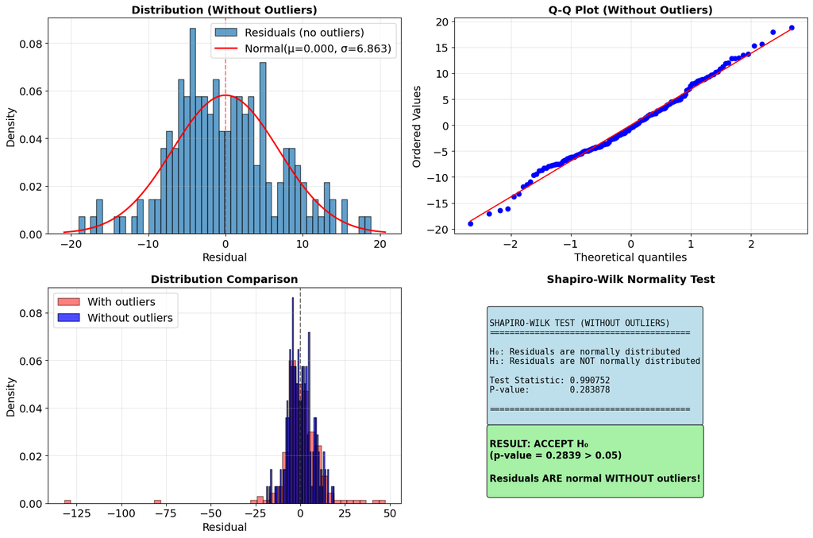

```
================================================================================
RESIDUAL STATISTICS (WITHOUT OUTLIERS)
================================================================================
  Mean:     0.000000
  Std Dev:  6.8629
  Skewness: 0.1569
  Kurtosis: 0.0896
================================================================================
```

```python
# Model Diagnostics (excluding outliers)
print("\n" + "="*80)
print("VISUALIZATIONS EXCLUDING OUTLIERS")
print("="*80)

fig, axes = plt.subplots(2, 2, figsize=(15, 10))

# Plot 1: Residual distribution WITH NORMAL OVERLAY
axes[0, 0].hist(residuals_no_outliers, bins=50, edgecolor='black', alpha=0.7, density=True, label='Residuals (no outliers)')
axes[0, 0].axvline(x=0, color='r', linestyle='--', alpha=0.5)

# Residual distribution with normal overlay plot
mu, std = residuals_no_outliers.mean(), residuals_no_outliers.std()
xmin, xmax = axes[0, 0].get_xlim()
x = np.linspace(xmin, xmax, 100)
p = norm.pdf(x, mu, std)
axes[0, 0].plot(x, p, 'r-', linewidth=2, label=f'Normal(μ={mu:.3f}, σ={std:.3f})')

axes[0, 0].set_title('Distribution (Without Outliers)', fontsize=14, fontweight='bold')
axes[0, 0].set_xlabel('Residual')
axes[0, 0].set_ylabel('Density')
axes[0, 0].legend()
axes[0, 0].grid(True, alpha=0.3)

# Plot 2: Q-Q Plot
stats.probplot(residuals_no_outliers, dist="norm", plot=axes[0, 1])
axes[0, 1].set_title('Q-Q Plot (Without Outliers)', fontsize=14, fontweight='bold')
axes[0, 1].grid(True, alpha=0.3)
# Plot 3: Distribution plot comparison (Before vs After)
axes[1, 0].hist(residuals_array, bins=50, edgecolor='black', alpha=0.5, density=True, label='With outliers', color='red')
axes[1, 0].hist(residuals_no_outliers, bins=50, edgecolor='black', alpha=0.7, density=True, label='Without outliers', color='blue')
axes[1, 0].axvline(x=0, color='black', linestyle='--', alpha=0.5)
axes[1, 0].set_title('Distribution Comparison', fontsize=14, fontweight='bold')
axes[1, 0].set_xlabel('Residual')
axes[1, 0].set_ylabel('Density')
axes[1, 0].legend()
axes[1, 0].grid(True, alpha=0.3)

# Plot 4: Shapiro-Wilk Test Result
axes[1, 1].axis('off')
axes[1, 1].set_title('Shapiro-Wilk Normality Test', fontsize=14, fontweight='bold')

# Perform Shapiro-Wilk test
shapiro_stat, shapiro_pvalue = shapiro(residuals_no_outliers)

# Create text summary
test_text = f"""
SHAPIRO-WILK TEST (WITHOUT OUTLIERS)
{'='*40}

H₀: Residuals are normally distributed
H₁: Residuals are NOT normally distributed

Test Statistic: {shapiro_stat:.6f}
P-value:        {shapiro_pvalue:.6f}

{'='*40}
"""

if shapiro_pvalue > 0.05:
    result_text = f"""
RESULT: ACCEPT H₀
(p-value = {shapiro_pvalue:.4f} > 0.05)

Residuals ARE normal WITHOUT outliers!
"""
    color = 'lightgreen'
else:
    result_text = f"""
RESULT: REJECT H₀
(p-value = {shapiro_pvalue:.4f} ≤ 0.05)

Residuals STILL not normal!
"""
    color = 'lightcoral'

axes[1, 1].text(0.1, 0.9, test_text, transform=axes[1, 1].transAxes,
                fontsize=11, verticalalignment='top', fontfamily='monospace',
                bbox=dict(boxstyle='round', facecolor='lightblue', alpha=0.8))

axes[1, 1].text(0.1, 0.35, result_text, transform=axes[1, 1].transAxes,
                fontsize=12, verticalalignment='top', fontweight='bold',
                bbox=dict(boxstyle='round', facecolor=color, alpha=0.8))

plt.tight_layout()
plt.show()

# Residual statistics
print("\n" + "="*80)
print("Residual Statistics (WITHOUT outliers)".upper())
print("="*80)

print(f"  Mean:     {residuals_no_outliers.mean():.6f}")
print(f"  Std Dev:  {residuals_no_outliers.std():.4f}")
print(f"  Skewness: {stats.skew(residuals_no_outliers):.4f}")
print(f"  Kurtosis: {stats.kurtosis(residuals_no_outliers):.4f}")

print("="*80)
```

**Comments**

- Skewness is low and the distribution shape looks symmetric. Therefore, skewness is acceptable.
- Kurtosis is very low indicating the massive influence of those 11 outliers. The distribution plot is also acceptable. Therefore, kurtosis is acceptable.
- The q-q plot looks very much like a normal plot and is acceptable.
- The Shapiro-Wilk test indicates no outliers highlighting the data as normal.
- Therefore, the data is normally distributed and the issue with normality was caused due to outliers.

**Next Steps**

### Analysis of Over-parameterized models

```python
# Overparameterized models
# AR(2) model
ar2_model = AutoReg(differenced_data, lags=2).fit()

# ARMA(1,1) model
arma_model = ARIMA(differenced_data, order=(1, 0, 1)).fit()

print("\n" + "="*80)
print("MODEL COEFFICIENTS COMPARISON")
print("="*80)

print("\n1. AR(1) MODEL:")
print("   Coefficients:")
print(ar1_fitted.params)
print("   Standard Errors:")
print(ar1_fitted.bse)

print("\n2. AR(2) MODEL:")
print("   Coefficients:")
print(ar2_model.params)
print("   Standard Errors:")
print(ar2_model.bse)

print("\n3. ARMA(1,1) MODEL:")
print("   Coefficients:")
print(arma_model.params[:-1])
print("   Standard Errors:")
print(arma_model.bse[:-1])

print("="*80)
```

```
================================================================================
MODEL COEFFICIENTS COMPARISON
================================================================================

1. AR(1) MODEL:
   Coefficients:
[0.31674566 0.25038687]
   Standard Errors:
[1.04309023 0.06932592]

2. AR(2) MODEL:
   Coefficients:
[0.30716639 0.22758684 0.09052357]
   Standard Errors:
[1.04427246 0.07151042 0.07165392]

3. ARMA(1,1) MODEL:
   Coefficients:
[ 0.40835293  0.60756663 -0.38697384]
   Standard Errors:
[2.25597626 0.20959951 0.21986393]
================================================================================
```

**Comments**

- **Comparison with AR(2)**
  - Coefficients of intercept and first parameter appear to be close to each other.
  - Therefore, AR(2) is not needed and the more parsimonious model, AR(1) is preferred.
- **Comparison with ARMA(1,1)**
  - AR coefficient and intercept are very different.
  - Additionally, AR(1) was chosen after giving up an MA(1) model.
  - Considering both of these, an ARIMA(1,1,1) would be trained next.

**Next Steps**

- Train ARIMA(1,1,1) model.
- Additionally, due to the presence of outlier residuals, most likely due to the spikes observed in the time plot, two parameter estimation methods would be used and compared:
  - Default method
  - Robust Estimation

### Determining best ARIMA(1,1,1) model parameter estimation method

```
================================================================================
MODEL COMPARISON - AIC
================================================================================

1. ARIMA(1,1,1) Default:
   AIC: 1609.2297

2. ARIMA(1,1,1) Robust (Hannan-Rissanen):
   AIC: 1610.3171

Difference (Standard - Robust): -1.0875
================================================================================
```

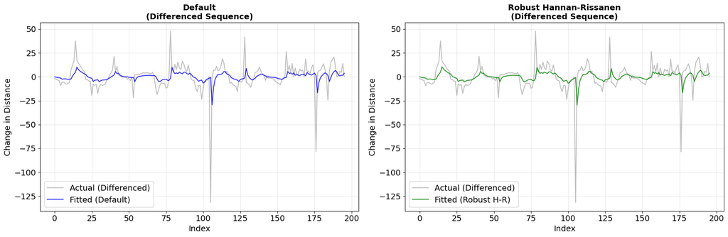

```python
# Method 1: Standard MLE
arima_standard = ARIMA(distance_from_center, order=(1, 1, 1)).fit()

# Method 2: Robust estimation (Hannan-Rissanen)
arima_robust = ARIMA(distance_from_center, order=(1, 1, 1)).fit(method='hannan_rissanen')

diff_actual = np.diff(distance_from_center)

resid_standard = arima_standard.resid[1:]
resid_robust = arima_robust.resid[1:]

fitted_diff_standard = diff_actual - resid_standard
fitted_diff_robust = diff_actual - resid_robust

print("\n" + "="*80)
print("MODEL COMPARISON - AIC")
print("="*80)
print(f"\n1. ARIMA(1,1,1) Default:")
print(f"   AIC: {arima_standard.aic:.4f}")
print(f"\n2. ARIMA(1,1,1) Robust (Hannan-Rissanen):")
print(f"   AIC: {arima_robust.aic:.4f}")
print(f"\nDifference (Standard - Robust): {arima_standard.aic - arima_robust.aic:.4f}")
print("="*80)

fig, axes = plt.subplots(1, 2, figsize=(18, 6))

# Plot 1: Standard MLE (Differenced Scale)
axes[0].plot(diff_actual, label='Actual (Differenced)', color='gray', alpha=0.5, linewidth=1.5)
axes[0].plot(fitted_diff_standard, label='Fitted (Default)', color='blue', alpha=0.8, linewidth=1.5)
axes[0].set_title('Default\n(Differenced Sequence)', fontsize=14, fontweight='bold')
axes[0].set_xlabel('Index')
axes[0].set_ylabel('Change in Distance')
axes[0].legend()
axes[0].grid(True, alpha=0.3)

# Plot 2: Robust H-R (Differenced Scale)
axes[1].plot(diff_actual, label='Actual (Differenced)', color='gray', alpha=0.5, linewidth=1.5)
axes[1].plot(fitted_diff_robust, label='Fitted (Robust H-R)', color='green', alpha=0.8, linewidth=1.5)
axes[1].set_title('Robust Hannan-Rissanen\n(Differenced Sequence)', fontsize=14, fontweight='bold')
axes[1].set_xlabel('Index')
axes[1].set_ylabel('Change in Distance')
axes[1].legend()
axes[1].grid(True, alpha=0.3)

plt.tight_layout()
plt.show()
```

**Comments**

- The differenced time plots are similar.
- The difference in AIC between the two models is very small.
- Considering the issues with outliers outlined earlier, robust estimation is chosen.

**Next Steps**

- Do a more detailed diagnostics for ARIMA(1,1,1).
- Choose between ARIMA(1,1,1) and AR(1).

### ARIMA(1,1,1) Diagnostics

```
================================================================================
VISUALIZATION - ARIMA(1,1,1) ROBUST ESTIMATION
================================================================================
```

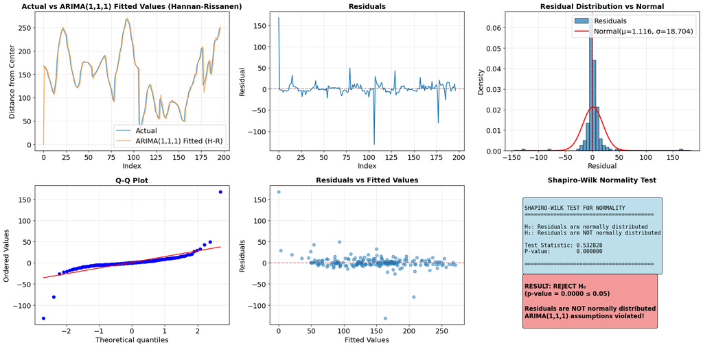

```
================================================================================
RESIDUAL STATISTICS
================================================================================
  Mean:     1.115957
  Std Dev:  18.7045
  Skewness: 1.5810
  Kurtosis: 44.1487
================================================================================

================================================================================
ARIMA(1,1,1) ROBUST MODEL SUMMARY
================================================================================
                               SARIMAX Results
==============================================================================
Dep. Variable:                      y   No. Observations:                  197
Model:                 ARIMA(1, 1, 1)   Log Likelihood                -802.159
Date:                Mon, 01 Dec 2025   AIC                           1610.317
Time:                        20:23:57   BIC                           1620.151
Sample:                             0   HQIC                          1614.299
                                - 197
Covariance Type:                  opg
==============================================================================
                 coef    std err          z      P>|z|      [0.025      0.975]
------------------------------------------------------------------------------
ar.L1          0.6519      0.201      3.239      0.001       0.257       1.046
ma.L1         -0.4307      0.215     -1.999      0.046      -0.853      -0.008
sigma2       231.7199      6.009     38.561      0.000     219.942     243.498
===================================================================================
Ljung-Box (L1) (Q):                   0.00   Jarque-Bera (JB):             12520.41
Prob(Q):                              0.98   Prob(JB):                         0.00
Heteroskedasticity (H):               3.03   Skew:                            -4.24
Prob(H) (two-sided):                  0.00   Kurtosis:                        41.23
===================================================================================

Warnings:
[1] Covariance matrix calculated using the outer product of gradients (complex-step).
```

```python
print("\n" + "="*80)
print("VISUALIZATION - ARIMA(1,1,1) ROBUST ESTIMATION")
print("="*80)

fig, axes = plt.subplots(2, 3, figsize=(20, 10))

resid_robust = arima_robust.resid
# Plot 1: Actual vs Fitted
axes[0, 0].plot(distance_from_center, label='Actual', linewidth=1.5, alpha=0.7)
axes[0, 0].plot(arima_robust.fittedvalues, label='ARIMA(1,1,1) Fitted (H-R)', linewidth=1.5, alpha=0.7)
axes[0, 0].set_title('Actual vs ARIMA(1,1,1) Fitted Values (Hannan-Rissanen)', fontsize=14, fontweight='bold')
axes[0, 0].set_xlabel('Index')
axes[0, 0].set_ylabel('Distance from Center')
axes[0, 0].legend()
axes[0, 0].grid(True, alpha=0.3)

# Plot 2: Residual plot
axes[0, 1].plot(resid_robust, linewidth=1.5)
axes[0, 1].axhline(y=0, color='r', linestyle='--', alpha=0.5)
axes[0, 1].set_title('Residuals', fontsize=14, fontweight='bold')
axes[0, 1].set_xlabel('Index')
axes[0, 1].set_ylabel('Residual')
axes[0, 1].grid(True, alpha=0.3)

# Plot 3: Residual distribution with normal overlay plot
axes[0, 2].hist(resid_robust, bins=50, edgecolor='black', alpha=0.7, density=True, label='Residuals')
axes[0, 2].axvline(x=0, color='r', linestyle='--', alpha=0.5)

# Overlay normal distribution
mu, std = resid_robust.mean(), resid_robust.std()
xmin, xmax = axes[0, 2].get_xlim()
x = np.linspace(xmin, xmax, 100)
p = norm.pdf(x, mu, std)
axes[0, 2].plot(x, p, 'r-', linewidth=2, label=f'Normal(μ={mu:.3f}, σ={std:.3f})')

axes[0, 2].set_title('Residual Distribution vs Normal', fontsize=14, fontweight='bold')
axes[0, 2].set_xlabel('Residual')
axes[0, 2].set_ylabel('Density')
axes[0, 2].legend()
axes[0, 2].grid(True, alpha=0.3)

# Plot 4: Q-Q Plot
stats.probplot(resid_robust, dist="norm", plot=axes[1, 0])
axes[1, 0].set_title('Q-Q Plot', fontsize=14, fontweight='bold')
axes[1, 0].grid(True, alpha=0.3)

# Plot 5: Residual scatter plot
axes[1, 1].scatter(arima_robust.fittedvalues, resid_robust, alpha=0.5)
axes[1, 1].axhline(y=0, color='r', linestyle='--', alpha=0.5)
axes[1, 1].set_title('Residuals vs Fitted Values', fontsize=14, fontweight='bold')
axes[1, 1].set_xlabel('Fitted Values')
axes[1, 1].set_ylabel('Residuals')
axes[1, 1].grid(True, alpha=0.3)

# Plot 6: Shapiro-Wilk Test Result
axes[1, 2].axis('off')
axes[1, 2].set_title('Shapiro-Wilk Normality Test', fontsize=14, fontweight='bold')

# Perform Shapiro-Wilk test
shapiro_stat, shapiro_pvalue = shapiro(resid_robust)

# Create text summary
test_text = f"""
SHAPIRO-WILK TEST FOR NORMALITY
{'='*40}

H₀: Residuals are normally distributed
H₁: Residuals are NOT normally distributed

Test Statistic: {shapiro_stat:.6f}
P-value:        {shapiro_pvalue:.6f}

{'='*40}
"""

if shapiro_pvalue > 0.05:
    result_text = f"""
RESULT: ACCEPT H₀
(p-value = {shapiro_pvalue:.4f} > 0.05)

Residuals ARE normally distributed
ARIMA(1,1,1) assumptions satisfied!
"""
    color = 'lightgreen'
else:
    result_text = f"""
RESULT: REJECT H₀
(p-value = {shapiro_pvalue:.4f} ≤ 0.05)

Residuals are NOT normally distributed
ARIMA(1,1,1) assumptions violated!
"""
    color = 'lightcoral'

axes[1, 2].text(0.1, 0.9, test_text, transform=axes[1, 2].transAxes,
                fontsize=11, verticalalignment='top', fontfamily='monospace',
                bbox=dict(boxstyle='round', facecolor='lightblue', alpha=0.8))

axes[1, 2].text(0.1, 0.35, result_text, transform=axes[1, 2].transAxes,
                fontsize=12, verticalalignment='top', fontweight='bold',
                bbox=dict(boxstyle='round', facecolor=color, alpha=0.8))

plt.tight_layout()
plt.show()

# Residual statistics
print("\n" + "="*80)
print("Residual Statistics".upper())
print("="*80)

print(f"  Mean:     {resid_robust.mean():.6f}")
print(f"  Std Dev:  {resid_robust.std():.4f}")
print(f"  Skewness: {stats.skew(resid_robust):.4f}")
print(f"  Kurtosis: {stats.kurtosis(resid_robust):.4f}")

print("="*80)

# %%
# Print model summary
print("\n" + "="*80)
print("ARIMA(1,1,1) ROBUST MODEL SUMMARY")
print("="*80)
print(arima_robust.summary())
```

**Comment**

### **Conclusion: AR(1) is best ARIMA(p,d,q) model in modelling simple cat sketches.**

## **Part 2: Sketching a Cat using Rolling Origin with Increasing Horizon VARIMA Forecasting**

### Finding Optimal VARIMA hyperparameters using grid search

```python
x = seq[:, 1]
y = seq[:, 2]

# Combine data
data_2d = pd.DataFrame({
    'x': x,
    'y': y
})

print("\n" + "="*80)
print("VARMAX AUTO MODEL SELECTION")
print("="*80)

# STEP 1: Auto-determine differencing order (d) using augmented Dickey-Fuller tests
print("\nSTEP 1: Determining differencing order (d)...")
print("-"*80)

def determine_d(series, max_d=2):
    for d in range(max_d + 1):
        if d == 0:
            test_series = series
        else:
            test_series = series.diff(d).dropna()

        adf_stat, adf_pval = adfuller(test_series)[:2]

        print(f"  d={d}: ADF p-value = {adf_pval:.4f}", end="")
        if adf_pval < 0.05:
            print(" ✅ STATIONARY")
            return d, test_series
        else:
            print(" ❌ Non-stationary")

    return max_d, series.diff(max_d).dropna()

# Check for each series
print("x:")
d_x, _ = determine_d(data_2d['x'])
print("y:")
d_y, _ = determine_d(data_2d['y'])

# Use maximum d
d_order = max(d_x, d_y)
print(f"\n✅ Selected d = {d_order}")

# Apply differencing
if d_order > 0:
    data_diff = data_2d.diff(d_order).dropna()
    print(f"   Applied {d_order} order differencing")
else:
    data_diff = data_2d
    print("   No differencing needed")

# STEP 2: Grid search for p and q using AIC
print("\n" + "="*80)
print("STEP 2: Grid search for optimal (p, q)...")
print("-"*80)

p_range = range(0, 4)  # Adjust if needed
q_range = range(0, 4)

best_aic = np.inf
best_order_aic = None
best_model_aic = None

results_list = []

total_combinations = (len(p_range) * len(q_range)) - 1  # -1 for (0,0)
current = 0

print(f"\nTesting {total_combinations} model combinations...\n")

for p, q in itertools.product(p_range, q_range):
    if p == 0 and q == 0:
        continue

    current += 1

    try:
        model = VARMAX(data_diff, order=(p, q), trend='c')
        fitted = model.fit(disp=False, maxiter=1000)

        aic = fitted.aic

        results_list.append({
            'p': p,
            'd': d_order,
            'q': q,
            'AIC': aic,
            'Converged': True
        })

        print(f"  [{current:2d}/{total_combinations}] VARMAX({p},{d_order},{q}): AIC={aic:8.2f}")

        # Track best by AIC
        if aic < best_aic:
            best_aic = aic
            best_order_aic = (p, d_order, q)
            best_model_aic = fitted

    except Exception as e: # Error handling to prevent loss of results
        print(f"  [{current:2d}/{total_combinations}] VARMAX({p},{d_order},{q}): FAILED")
        results_list.append({
            'p': p,
            'd': d_order,
            'q': q,
            'AIC': np.nan,
            'Converged': False
        })

# STEP 3: Display results
print("\n" + "="*80)
print("🏆 BEST MODELS")
print("="*80)
print(f"\nBy AIC: VARMAX{best_order_aic}")
print(f"  AIC = {best_aic:.4f}")

# Show comparison table
results_df = pd.DataFrame(results_list)
results_df_converged = results_df[results_df['Converged'] == True].copy()

print("\n" + "="*80)
print("ALL SUCCESSFUL MODELS (sorted by AIC)")
print("="*80)
print(results_df_converged.sort_values('AIC').to_string(index=False))

# Use best model by AIC
best_model = best_model_aic
best_order = best_order_aic

print("\n" + "="*80)
print(f"✅ SELECTED MODEL: VARMAX{best_order}")
print("="*80)
print(best_model.summary())

# Store for later use
varmax_final = best_model
varmax_order = best_order
varmax_resid = best_model.resid

print("\n" + "="*80)
print("✅ MODEL SELECTION COMPLETE!")
print(f"   Final model: VARMAX{varmax_order}")
print(f"   AIC: {best_model.aic:.4f}")
print("="*80)
```

```
================================================================================
VARMAX AUTO MODEL SELECTION
================================================================================

STEP 1: Determining differencing order (d)...
--------------------------------------------------------------------------------
x:
  d=0: ADF p-value = 0.2878 ❌ Non-stationary
  d=1: ADF p-value = 0.0000 ✅ STATIONARY
y:
  d=0: ADF p-value = 0.0569 ❌ Non-stationary
  d=1: ADF p-value = 0.0000 ✅ STATIONARY

✅ Selected d = 1
   Applied 1 order differencing

================================================================================
STEP 2: Grid search for optimal (p, q)...
--------------------------------------------------------------------------------

Testing 15 model combinations...

  [ 1/15] VARMAX(0,1,1): AIC= 3639.43
  [ 2/15] VARMAX(0,1,2): AIC= 3642.23
  [ 3/15] VARMAX(0,1,3): AIC= 3646.66
  [ 4/15] VARMAX(1,1,0): AIC= 3636.70
  [ 5/15] VARMAX(1,1,1): AIC= 3614.92
  [ 6/15] VARMAX(1,1,2): AIC= 3623.78
  [ 7/15] VARMAX(1,1,3): AIC= 3643.75
  [ 8/15] VARMAX(2,1,0): AIC= 3637.95
  [ 9/15] VARMAX(2,1,1): AIC= 3621.09
  [10/15] VARMAX(2,1,2): AIC= 3627.61
  [11/15] VARMAX(2,1,3): AIC= 3631.99
  [12/15] VARMAX(3,1,0): AIC= 3641.54
  [13/15] VARMAX(3,1,1): AIC= 3628.27
  [14/15] VARMAX(3,1,2): AIC= 3633.41
  [15/15] VARMAX(3,1,3): AIC= 3635.75

================================================================================
🏆 BEST MODELS
```

[output cut: 63 more lines]

```
                   coef    std err          z      P>|z|      [0.025      0.975]
--------------------------------------------------------------------------------
sqrt.var.x      30.7354      1.808     16.996      0.000      27.191      34.280
sqrt.cov.x.y    -2.0917      0.738     -2.835      0.005      -3.538      -0.646
sqrt.var.y      17.8952      0.883     20.259      0.000      16.164      19.626
================================================================================

Warnings:
[1] Covariance matrix calculated using the outer product of gradients (complex-step).

================================================================================
✅ MODEL SELECTION COMPLETE!
   Final model: VARMAX(1, 1, 1)
   AIC: 3614.9224
================================================================================
```

### Analysing VARIMA’s ability in drawing a cat

```python
# Rolling Origin with Increasing Horizon forecasting - FIT AT EACH POINT AND FORECAST H (increases with each iteration) STEPS AHEAD
# Cat will be sketched using the H-th step only
# Many cats will be drawn for different H and the quality degradation will be analyzed

print("\n" + "="*80)
print("🐱 Rolling Origin with Increasing Horizon forecasting - BUILD CAT FROM H-STEP FORECASTS".upper())
print("="*80)

MAX_FORECAST_HORIZON = [1, 2, 5, 10, 20, 30, 50, 100]  # maximum forecast horizon
max_steps = max(MAX_FORECAST_HORIZON) # The furthest we ever need to look ahead
min_horizon = min(MAX_FORECAST_HORIZON) # The latest we can possibly start stopping

p, d, q = varmax_order  # From best model

print(f"\nConfiguration:")
print(f"  Model order: VARMAX({p}, {d}, {q})")
print(f"  Maximum forecast horizon: {MAX_FORECAST_HORIZON}")
print(f"  Total actual data points: {len(data_2d)}")

data_2d_float = data_2d[['x', 'y']].astype(float).copy() # fix VARMAX data type issue

forecast_storage = {h: [] for h in MAX_FORECAST_HORIZON}

success_count = 0
fail_count = 0

print(f"\n{'='*80}")
print(f"🔮 Processing Rolling Origin Forecasts (Max Horizon: {max_steps})")
print(f"{'='*80}")

# Loop until the end of data minus the smallest horizon.
# Larger horizons will simply stop collecting data earlier within the loop.
loop_end = len(data_2d_float) - min_horizon

for i in range(p+d+1, loop_end):

    train_data = data_2d_float.iloc[:i+1].copy()

    try:
        model = VARMAX(train_data, order=(p, q), trend='c')
        model_fit = model.fit(disp=False, maxiter=500, warn_convergence=False)

        forecast = model_fit.forecast(steps=max_steps)

        # Distribute the forecast steps to their respective horizon buckets
        for h in MAX_FORECAST_HORIZON:
            # Edge Case
            if i + h < len(data_2d_float):

                forecasted_x = forecast.iloc[h-1, 0]
                forecasted_y = forecast.iloc[h-1, 1]

                forecast_storage[h].append({
                    'original_index': i + h,
                    'x': forecasted_x,
                    'y': forecasted_y
                })

        success_count += 1

        if (i + 1) % 20 == 0:
             print(f"  Progress: {i+1}/{loop_end} | Fits: {success_count} | Fails: {fail_count}", end='\r')

    except Exception as e:
        fail_count += 1
        if fail_count <= 3:
            print(f"\n  ⚠️ Model fit failed at i={i} (train size={len(train_data)}): {str(e)[:80]}")
        continue

# Convert lists to DataFrames
all_forecasted_cats = {}
for h in MAX_FORECAST_HORIZON:
    all_forecasted_cats[h] = pd.DataFrame(forecast_storage[h])
    print(f"\nHorizon {h}: Generated {len(all_forecasted_cats[h])} points")

print(f"\nTotal Fits: {success_count}, Total Failed Fits: {fail_count}")
```

```
================================================================================
🐱 ROLLING ORIGIN WITH INCREASING HORIZON FORECASTING - BUILD CAT FROM H-STEP FORECASTS
================================================================================

Configuration:
  Model order: VARMAX(1, 1, 1)
  Maximum forecast horizon: [1, 2, 5, 10, 20, 30, 50, 100]
  Total actual data points: 197

================================================================================
🔮 Processing Rolling Origin Forecasts (Max Horizon: 100)
================================================================================

  ⚠️ Model fit failed at i=3 (train size=4): Matrix is not positive definite
  Progress: 180/196 | Fits: 176 | Fails: 1
Horizon 1: Generated 192 points

Horizon 2: Generated 191 points

Horizon 5: Generated 188 points

Horizon 10: Generated 183 points

Horizon 20: Generated 173 points

Horizon 30: Generated 163 points

Horizon 50: Generated 143 points

Horizon 100: Generated 93 points

Total Fits: 192, Total Failed Fits: 1
```

```
================================================================================
Creating cat decay plots...
================================================================================
```

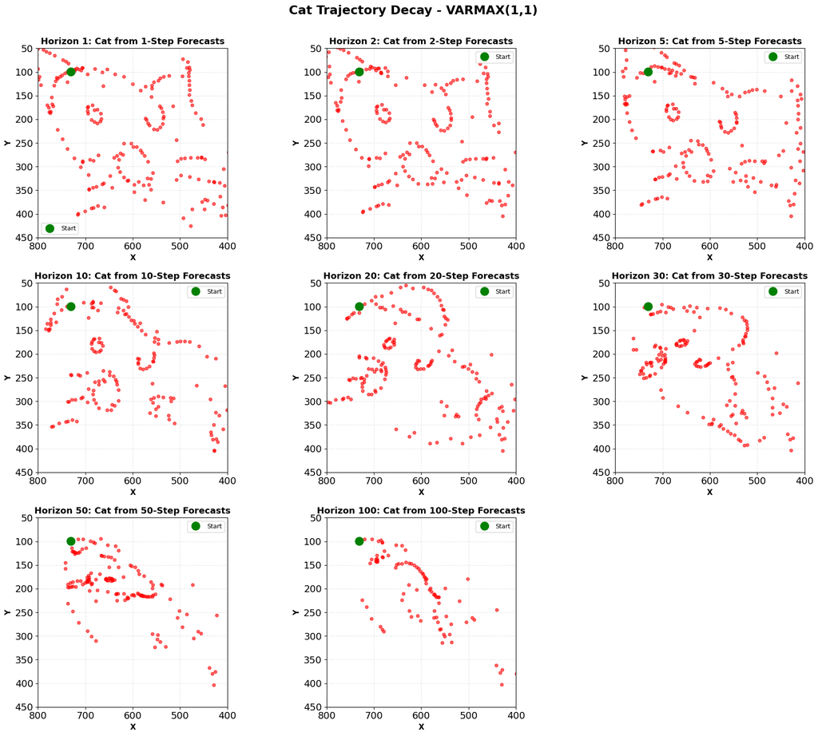

```
✅ Saved: cat_forecast_decay.png

================================================================================
Creating cat decay plot comparison...
================================================================================
```

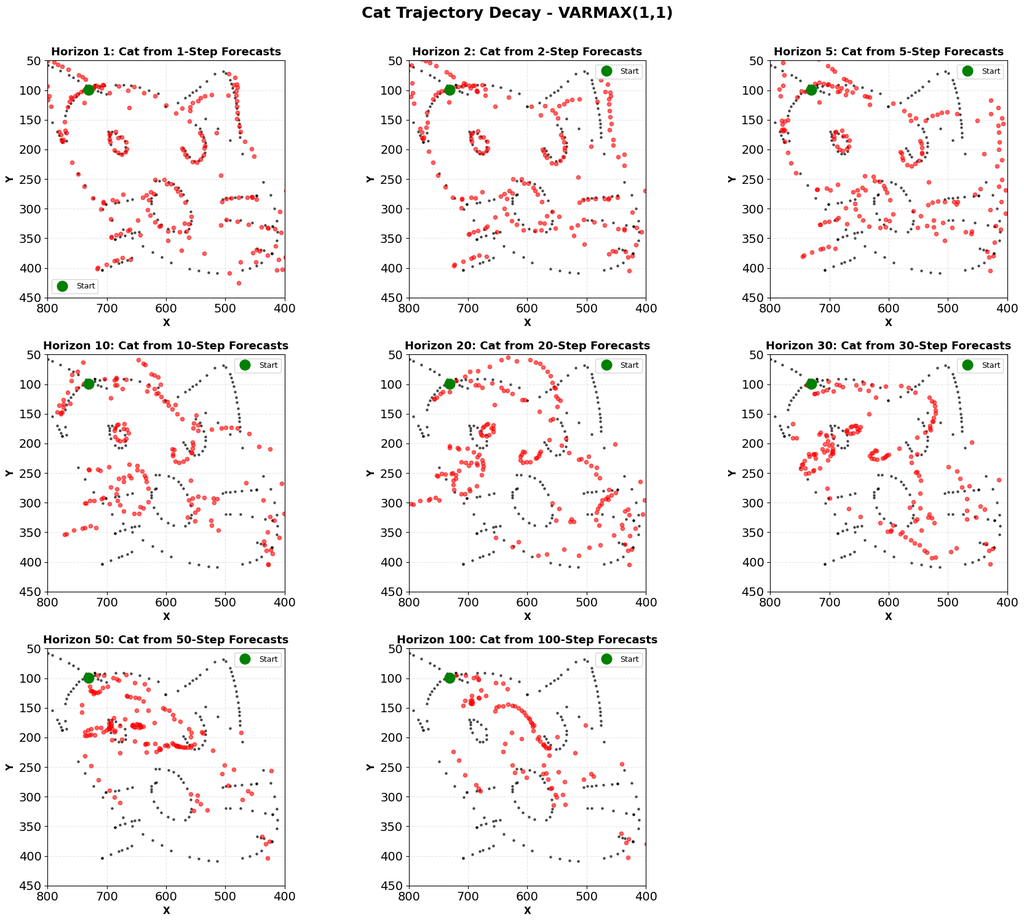

```
✅ Saved: cat_forecast_comparison.png
```

```python
print("\n" + "="*80)
print("Creating cat decay plots...")
print("="*80)

n_cols = min(3, len(MAX_FORECAST_HORIZON))
n_rows = int(np.ceil(len(MAX_FORECAST_HORIZON) / n_cols))

fig, axes = plt.subplots(n_rows, n_cols, figsize=(6*n_cols, 5*n_rows))
axes = axes.flatten() if len(MAX_FORECAST_HORIZON) > 1 else [axes]

for idx, (horizon, forecast_df) in enumerate(all_forecasted_cats.items()):
    ax = axes[idx]

    # Forecasted plot
    if len(forecast_df) > 0:
        ax.scatter(forecast_df['x'], forecast_df['y'], c='red', s=20, alpha=0.6)

    # Mark start
    ax.plot(data_2d.iloc[0]['x'], data_2d.iloc[0]['y'],
            'o', color='green', markersize=12, label='Start', zorder=5)

    ax.set_xlabel('X', fontsize=11, fontweight='bold')
    ax.set_ylabel('Y', fontsize=11, fontweight='bold')
    ax.set_title(f'Horizon {horizon}: Cat from {horizon}-Step Forecasts',
                fontsize=13, fontweight='bold')
    ax.legend(loc='best', fontsize=9)
    ax.grid(True, alpha=0.3, linestyle='--')
    ax.set_aspect('equal', adjustable='box')
    ax.set_ylim(50, 450)
    ax.set_xlim(400, 800)
    ax.invert_xaxis()
    ax.invert_yaxis()

# Hide extra subplots
for idx in range(len(MAX_FORECAST_HORIZON), len(axes)):
    axes[idx].set_visible(False)

plt.suptitle(f'Cat Trajectory Decay - VARMAX({p},{q})',
                fontsize=18, fontweight='bold', y=1.00)
plt.tight_layout()
plt.savefig('cat_forecast_decay.png', dpi=150, bbox_inches='tight')
plt.show()

print("\n✅ Saved: cat_forecast_decay.png")



print("\n" + "="*80)
print("Creating cat decay plot comparison...")
print("="*80)

fig, axes = plt.subplots(n_rows, n_cols, figsize=(6*n_cols, 5*n_rows))
axes = axes.flatten() if len(MAX_FORECAST_HORIZON) > 1 else [axes]

for idx, (horizon, forecast_df) in enumerate(all_forecasted_cats.items()):
    ax = axes[idx]

    # Actual plot
    ax.scatter(data_2d['x'], data_2d['y'], c='black', s=5, alpha=0.6)

    # Forecasted plot
    if len(forecast_df) > 0:
        ax.scatter(forecast_df['x'], forecast_df['y'], c='red', s=20, alpha=0.6)

    # Mark start
    ax.plot(data_2d.iloc[0]['x'], data_2d.iloc[0]['y'],
            'o', color='green', markersize=12, label='Start', zorder=5)

    ax.set_xlabel('X', fontsize=11, fontweight='bold')
    ax.set_ylabel('Y', fontsize=11, fontweight='bold')
    ax.set_title(f'Horizon {horizon}: Cat from {horizon}-Step Forecasts',
                fontsize=13, fontweight='bold')
    ax.legend(loc='best', fontsize=9)
    ax.grid(True, alpha=0.3, linestyle='--')
    ax.set_aspect('equal', adjustable='box')
    ax.set_ylim(50, 450)
    ax.set_xlim(400, 800)
    ax.invert_xaxis()
    ax.invert_yaxis()

# Hide extra subplots
for idx in range(len(MAX_FORECAST_HORIZON), len(axes)):
    axes[idx].set_visible(False)

plt.suptitle(f'Cat Trajectory Decay - VARMAX({p},{q})',
                fontsize=18, fontweight='bold', y=1.00)
plt.tight_layout()
plt.savefig('cat_forecast_comparison.png', dpi=150, bbox_inches='tight')
plt.show()

print("\n✅ Saved: cat_forecast_comparison.png")
```

```
================================================================================
Creating cat decay trajectory plots...
================================================================================
```

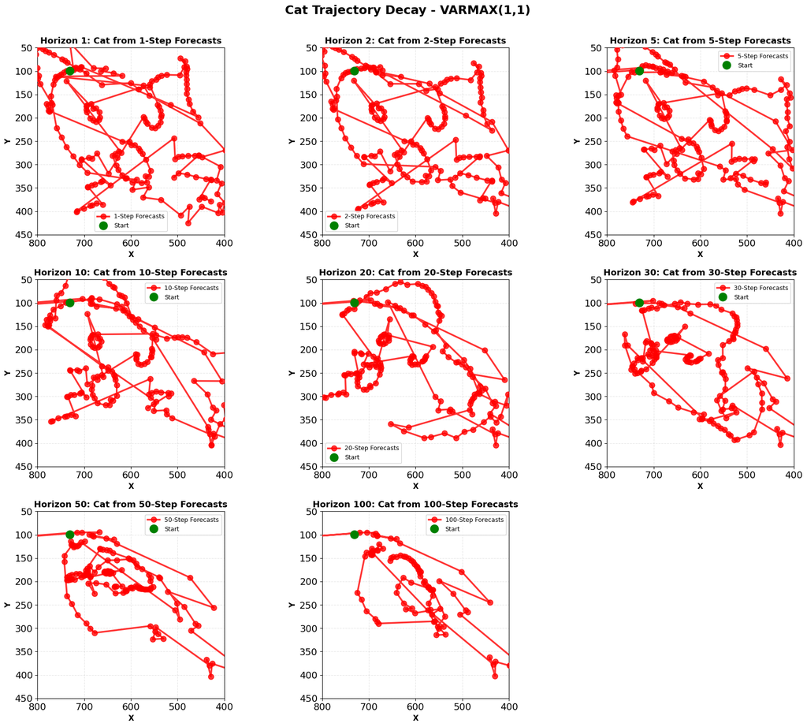

```
✅ Saved: cat_forecast_decay_trajectory.png
```

```python
print("\n" + "="*80)
print("Creating cat decay trajectory plots...")
print("="*80)

fig, axes = plt.subplots(n_rows, n_cols, figsize=(6*n_cols, 5*n_rows))
axes = axes.flatten() if len(MAX_FORECAST_HORIZON) > 1 else [axes]

for idx, (horizon, forecast_df) in enumerate(all_forecasted_cats.items()):
    ax = axes[idx]

    # Plot forecasted trajectory
    if len(forecast_df) > 0:
        ax.plot(forecast_df['x'], forecast_df['y'],
                'o-', color='red', linewidth=2.5, markersize=8,
                label=f'{horizon}-Step Forecasts', alpha=0.8, zorder=4)

    # Mark start
    ax.plot(data_2d.iloc[0]['x'], data_2d.iloc[0]['y'],
            'o', color='green', markersize=12, label='Start', zorder=5)

    ax.set_xlabel('X', fontsize=11, fontweight='bold')
    ax.set_ylabel('Y', fontsize=11, fontweight='bold')
    ax.set_title(f'Horizon {horizon}: Cat from {horizon}-Step Forecasts',
                fontsize=13, fontweight='bold')
    ax.legend(loc='best', fontsize=9)
    ax.grid(True, alpha=0.3, linestyle='--')
    ax.set_aspect('equal', adjustable='box')
    ax.set_ylim(50, 450)
    ax.set_xlim(400, 800)
    ax.invert_xaxis()
    ax.invert_yaxis()

# Hide extra subplots
for idx in range(len(MAX_FORECAST_HORIZON), len(axes)):
    axes[idx].set_visible(False)

plt.suptitle(f'Cat Trajectory Decay - VARMAX({p},{q})',
                fontsize=18, fontweight='bold', y=1.00)
plt.tight_layout()
plt.savefig('cat_forecast_decay_trajectory.png', dpi=150, bbox_inches='tight')
plt.show()

print("\n✅ Saved: cat_forecast_decay_trajectory.png")
```

**Comments**

- As the number of forecast steps increases:
  - The cat degrades.
  - The cat rotates away.
  - The cat's lower half disappears.
- This shows that VARIMA learns some ability to sketch a cat when rolling origin with increasing horizon forecasting is used.
- However, this ability degrades quickly as the forecast steps increase.

## **Sources**

1. dataset: https://console.cloud.google.com/storage/browser/_details/quickdraw_dataset/full/raw/cat.ndjson;tab=live_object
2. quickdraw website: https://quickdraw.withgoogle.com/data
3. github: https://github.com/googlecreativelab/quickdraw-dataset